# Monarch_Manuscript

Author

Calvin Belton & James Walters

# 1 Setting up

```r
library(flexsurv)
library(ggplot2)
library(tidyverse)
library(ggfortify)# for `autoplot` with survfit
library(survminer)
library(kableExtra)
library(patchwork)
library(splines)
library(muhaz)
```

## 1.1 Load and Clean Data

## 1.2 Read Data

```r
monsurv_full <- read.csv(("../Input_Data/MonarchAgingData_2026_01_08.csv"))
```

### 1.2.1 Clean sex column, remove extra whitespace, invalid/missing entries, and calculate age.

In the dataset, some butterflies were incorrectly labeled with an extra space in the ‘Sex’ column (e.g., ‘Female’ instead of ‘Female’), which led to the appearance of an unintended third category. This step trims whitespace to ensure consistent labeling and filters the data to include only valid sex categories (‘Male’ and ‘Female’). Additionally, the female at age 85 was excluded as an outlier, since the eclosion date on this individual was difficult to read, and therefore considered unreliable.

```r
monsurv <- monsurv_full %>%
  mutate(Sex = str_trim(Sex)) %>%
  filter(Sex %in% c("Male", "Female")) %>%
  mutate(
    DeathDate = as.Date(DeathDate),
    EclosionDate = as.Date(EclosionDate),
    AgeCalc = DeathDate - EclosionDate
  ) %>%
  filter(Age < 84)  # Remove age outliers
tapply(monsurv$Age, monsurv$Sex, FUN=summary)
```

```
$Female
   Min. 1st Qu.  Median    Mean 3rd Qu.    Max.
   3.00   20.00   25.00   24.95   29.00   73.00

$Male
   Min. 1st Qu.  Median    Mean 3rd Qu.    Max.
   2.00   20.00   27.00   26.97   33.00   72.00
```

### 1.2.2 Check to see if there’s any difference between ‘AgeCalc’ and ‘Age’

There is not, we can move forward in the analysis using the variable ‘Age’.

```r
any(monsurv_full$AgeCalc != monsurv_full$Age)
```

```
[1] FALSE
```

### 1.2.3 Configure Sex as Factor (male as the reference)

```r
monsurv$Sex <- factor(monsurv$Sex, levels = c("Male", "Female"))
```

### 1.2.4 Add “Event” column for survival analysis

All observed dead; None are censored so all are 1

```r
monsurv$event <- 1
```

### 1.2.5 Z-scale wing disc to aid in interpretation

This centers and scales the data .

```r
monsurv$FWdc_z <- as.numeric(scale(monsurv$Discal.cell.forewing))
```

## 1.3 Save out ‘cleaned’ dataset for subsequent scripts

```r
save(monsurv, file = "../Input_Data/monsurv.Rdata")
```

Before I start creating plots, I set up the custom theme and custom color palette that is continuous in my plots of monarch.

## 1.4 Custom theme

```r
theme_monarch <- theme_bw(base_size = 12) +
  theme(
    plot.title = element_text(face = "bold", hjust = 0.5, size = 14),
    axis.title = element_text(face = "bold", size = 13),
    axis.text = element_text(face = "bold", size = 11),
    strip.text = element_text(face = "bold")
  )
```

## 1.5 Define color palette for sex

```r
sex_colors <- c("Male" = "dodgerblue","Female" = "firebrick2")
```

# 2 Histogram of Age in each Sex

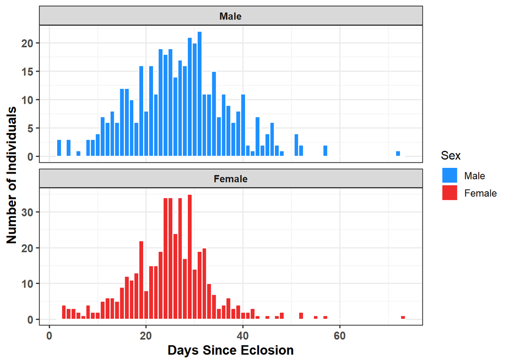

```r
full_histo_plot <- monsurv %>%
  filter(!is.na(Sex)) %>%
  ggplot(aes(x = Age, fill = Sex)) +
  geom_histogram(binwidth = 1, color = "white") +
  facet_wrap(~Sex, scales = "free_y", ncol = 1) +
  scale_fill_manual(values = sex_colors) +
  labs(
    x = "Days Since Eclosion",
    y = "Number of Individuals") +
  theme_monarch

print(full_histo_plot)
```

### 2.0.1 Save histogram of age by sex

```r
ggsave(
  filename = "../Results/Descriptive_Results/Figures/Figure_01_age_histogram.pdf",
  plot = full_histo_plot,
  width = 180,
  height = 120,
  units = "mm",
  dpi = 300
)
```

## 2.1 Plot the distribution of the eclosion dates

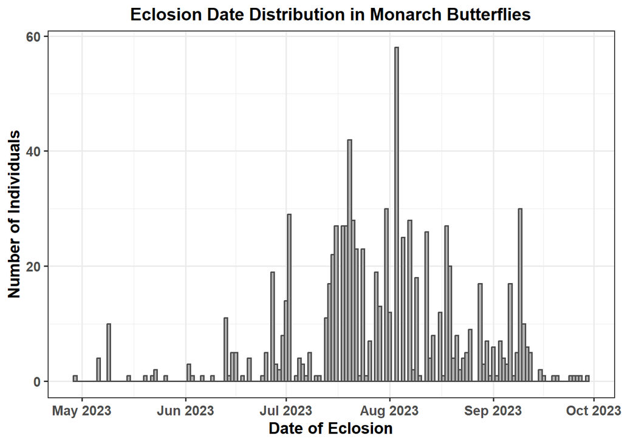

```r
eclosion_distribution <- monsurv %>%
  ggplot(aes(x = EclosionDate)) +
  geom_histogram(binwidth = 1, fill = "grey70", color = "grey30") +
  labs(
    title = "Eclosion Date Distribution in Monarch Butterflies",
    x = "Date of Eclosion",
    y = "Number of Individuals"
  ) +
  scale_x_date(
    date_breaks = "1 month",
    date_labels = "%b %Y"
  ) + theme_monarch

print(eclosion_distribution)
```

### 2.1.1 Save eclosion distribution plot

```r
ggsave(
  filename = "../Results/Descriptive_Results/Figures/Figure_02_eclosion_distribution.jpg",
  plot = eclosion_distribution,
  width = 180,
  height = 120,
  units = "mm",
  dpi = 300
)
```

## 2.2 Plot the distribution of death dates

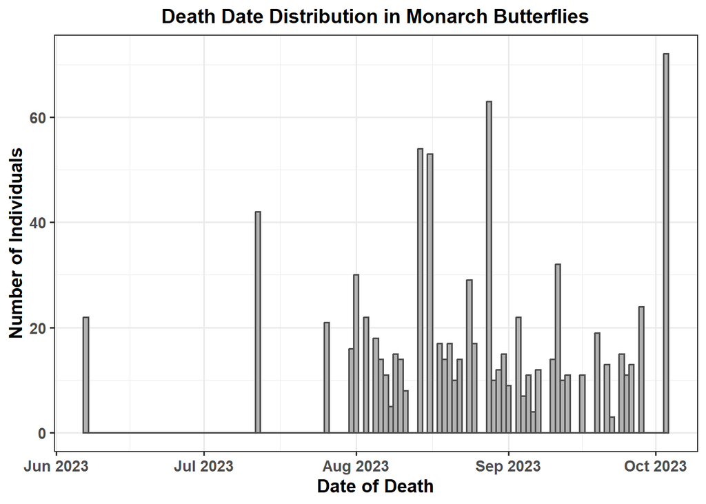

```r
death_distribution <- monsurv %>%
  ggplot(aes(x = DeathDate)) +
  geom_histogram(binwidth = 1, fill = "grey70", color = "grey30") +
  labs(
    title = "Death Date Distribution in Monarch Butterflies",
    x = "Date of Death",
    y = "Number of Individuals"
  ) +
  scale_x_date(
    date_breaks = "1 month",       # adjust based on your data span
    date_labels = "%b %Y"          # e.g., Jan 2023
  ) + theme_monarch

print(death_distribution)
```

### 2.2.1 Save death distribution plot

```r
ggsave(
  filename = "../Results/Descriptive_Results/Figures/Figure_03_death_distribution.jpg",
  plot = death_distribution,
  width = 180,
  height = 120,
  units = "mm",
  dpi = 300
)
```

## 2.3 Tabulate missing values for size measures in each sex

```r
monsurv %>%
  filter(Sex %in% c("Male", "Female")) %>%
  mutate(missing_wing = is.na(WingLength)) %>%
  count(Sex, missing_wing)
```

```
     Sex missing_wing   n
1   Male        FALSE 298
2   Male         TRUE 126
3 Female        FALSE 426
4 Female         TRUE  26
```

# 3 Descriptive Statistics concerning Size

## 3.1 Summary of Winglength

```r
tapply(monsurv$WingLength, monsurv$Sex, FUN=summary)
```

```
$Male
   Min. 1st Qu.  Median    Mean 3rd Qu.    Max.     NAs
  37.38   43.69   45.66   45.59   47.49   55.11     126

$Female
   Min. 1st Qu.  Median    Mean 3rd Qu.    Max.     NAs
  34.71   43.36   45.55   45.61   47.62   54.15      26
```

## 3.2 Summary of Forewing discal cell size

```r
tapply(monsurv$Discal.cell.forewing, monsurv$Sex, FUN=summary)
```

```
$Male
   Min. 1st Qu.  Median    Mean 3rd Qu.    Max.
  1.904   2.400   2.517   2.513   2.622   3.302

$Female
   Min. 1st Qu.  Median    Mean 3rd Qu.    Max.
  1.896   2.266   2.383   2.381   2.485   2.859
```

## 3.3 Boxplot of Winglength

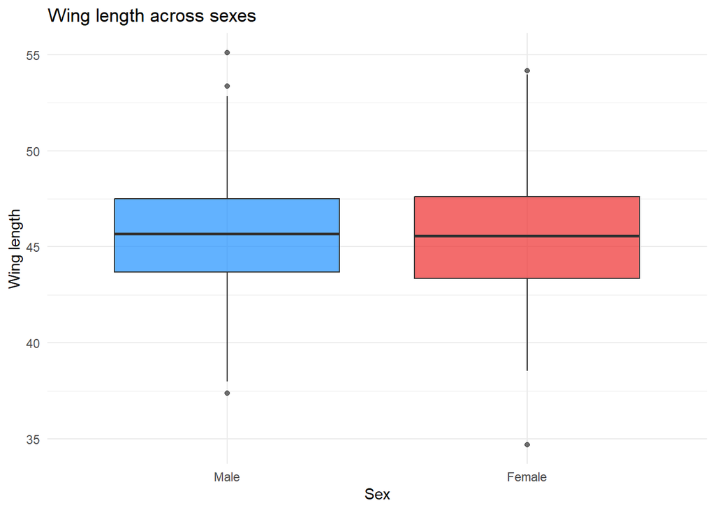

```r
winglength_boxplot <- ggplot(monsurv, aes(x = Sex, y = WingLength, fill = Sex)) +
  geom_boxplot(alpha = 0.7) +
  scale_fill_manual(values = sex_colors) +
  theme_minimal() +
  labs(
    title = "Wing length across sexes",
    x = "Sex",
    y = "Wing length"
  ) +
  theme(legend.position = "none")
print(winglength_boxplot)
```

#### 3.3.0.1 Save Boxplot of Winglength

```r
ggsave(
  filename = "../Results/Descriptive_Results/Figures/Figure_04_winglength_boxplot.jpg",
  plot = winglength_boxplot,
  width = 180,
  height = 120,
  units = "mm",
  dpi = 300
)
```

## 3.4 Boxplot of Forewing discal cell length

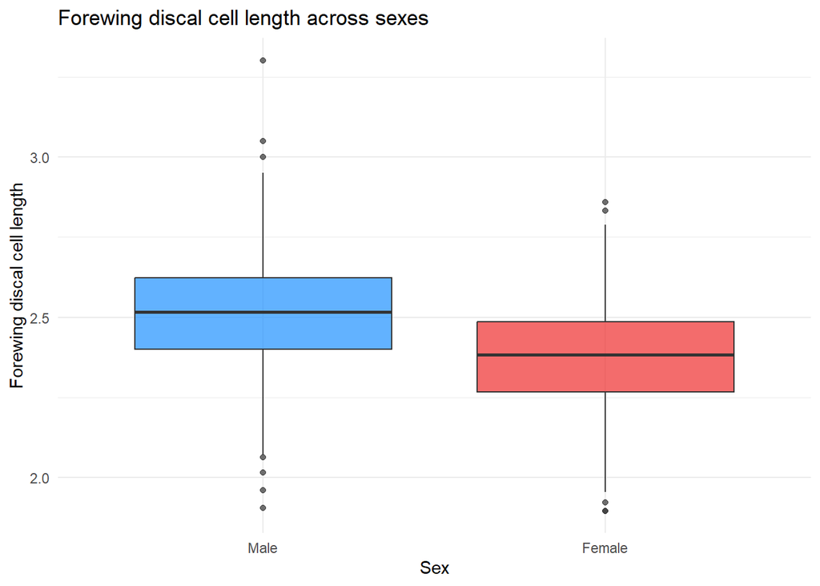

```r
forewing_boxplot <- ggplot(monsurv, aes(x = Sex, y = Discal.cell.forewing, fill = Sex)) +
  geom_boxplot(alpha = 0.7) +
  scale_fill_manual(values = sex_colors) +
  theme_minimal() +
  labs(
    title = "Forewing discal cell length across sexes",
    x = "Sex",
    y = "Forewing discal cell length"
  ) +
  theme(legend.position = "none")
print(forewing_boxplot)
```

#### 3.4.0.1 Save Boxplot of Forewing discal cell length

```r
ggsave(
  filename = "../Results/Descriptive_Results/Figures/Figure_05_forewing_boxplot.jpg",
  plot = forewing_boxplot,
  width = 180,
  height = 120,
  units = "mm",
  dpi = 300
)
```

#### 3.4.0.2 Histogram of Forewing discal cell length

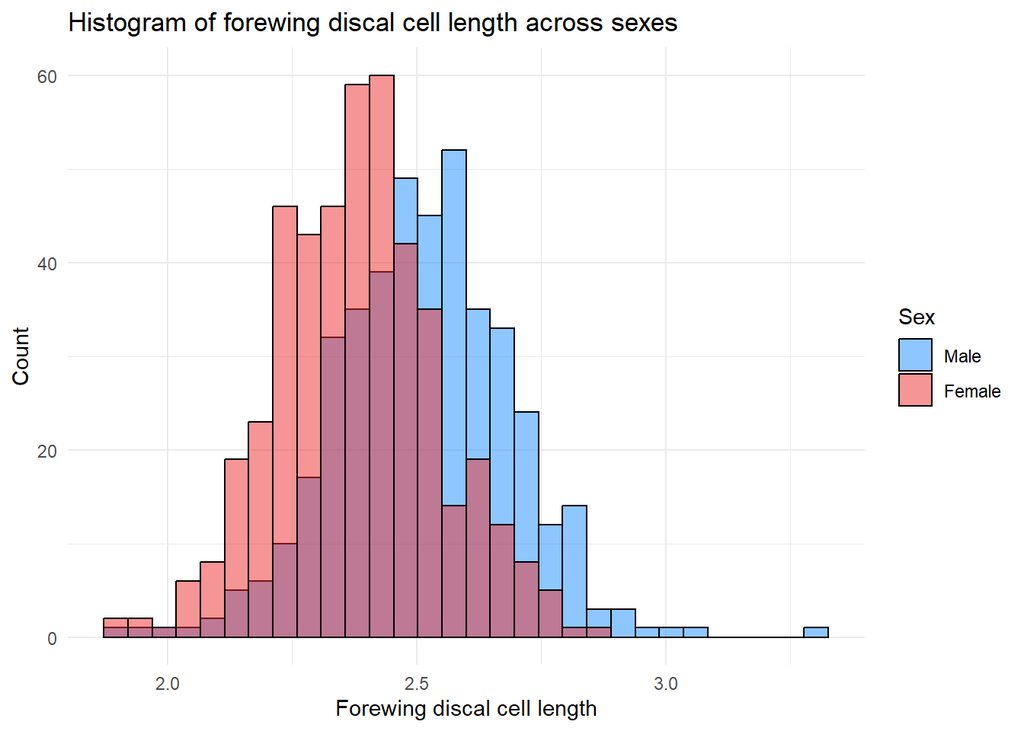

```r
forewing_histo <- ggplot(monsurv, aes(Discal.cell.forewing, fill = Sex)) +
  geom_histogram(
    bins = 30,
    alpha = 0.5,
    position = "identity",
    color = "black"
  ) +
  scale_fill_manual(values = sex_colors) +
  theme_minimal() +
  labs(
    title = "Histogram of forewing discal cell length across sexes",
    x = "Forewing discal cell length",
    y = "Count"
  )
print(forewing_histo)
```

#### 3.4.0.3 Save Histogram of Forewing discal cell length

```r
ggsave(
  filename = "../Results/Descriptive_Results/Figures/Figure_06_forewing_histogram.jpg",
  plot = forewing_histo,
  width = 180,
  height = 120,
  units = "mm",
  dpi = 300
)
```

### 3.4.1 Correlation between Winglength and Discal cell forewing length Plot

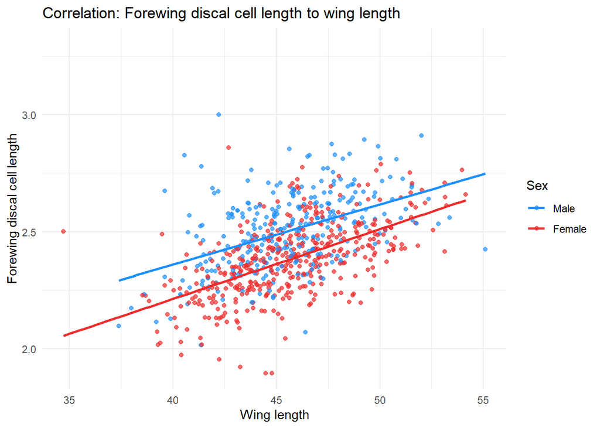

```r
correlation_wing_forewing <- ggplot(monsurv, aes(WingLength, Discal.cell.forewing, color = Sex)) +
  geom_point(alpha = 0.7) +
  geom_smooth(method = "lm", se = FALSE) +
  scale_color_manual(values = sex_colors) +
  theme_minimal() +
  labs(
    title = "Correlation: Forewing discal cell length to wing length",
    x = "Wing length",
    y = "Forewing discal cell length",
    color = "Sex"
  )
print(correlation_wing_forewing)
```

#### 3.4.1.1 Save Correlation between Winglength and Discal cell forewing length Plot

```r
ggsave(
  filename = "../Results/Descriptive_Results/Figures/Figure_07_correlation_wing_forewing.jpg",
  plot = correlation_wing_forewing,
  width = 180,
  height = 120,
  units = "mm",
  dpi = 300
)
```

## 3.5 T-tests

```r
stats_file <- "../Results/Descriptive_Results/Statistics/t_test_results.txt"

cat(
  "Monarch Manuscript T-test Results\n",
  "=================================\n\n",
  file = stats_file
)
```

```r
save_test <- function(test_obj, label, file){

  cat(
    "\n-----------------------------------\n",
    label,
    "\n-----------------------------------\n",
    file = file,
    append = TRUE
  )

  capture.output(
    test_obj,
    file = file,
    append = TRUE
  )
}
```

### 3.5.1 Age t-test

```r
age_ttest <- t.test(Age ~ Sex, data = monsurv)
age_ttest
```

```
    Welch Two Sample t-test

data:  Age by Sex
t = 3.1865, df = 827.66, p-value = 0.001494
alternative hypothesis: true difference in means between group Male and group Female is not equal to 0
95 percent confidence interval:
 0.7757281 3.2644289
sample estimates:
  mean in group Male mean in group Female
            26.96698             24.94690
```

```r
save_test(age_ttest, "Age t-test", stats_file)
```

### 3.5.2 Winglength t-test

```r
wing_ttest <- t.test(WingLength ~ Sex, data = monsurv)
wing_ttest
```

```
    Welch Two Sample t-test

data:  WingLength by Sex
t = -0.11185, df = 665.32, p-value = 0.911
alternative hypothesis: true difference in means between group Male and group Female is not equal to 0
95 percent confidence interval:
 -0.4672415  0.4168802
sample estimates:
  mean in group Male mean in group Female
            45.58962             45.61480
```

```r
save_test(wing_ttest, "Winglength t-test", stats_file)
```

### 3.5.3 Discal cell t-test

```r
discal_ttest <- t.test(Discal.cell.forewing ~ Sex, data = monsurv)
discal_ttest
```

```
    Welch Two Sample t-test

data:  Discal.cell.forewing by Sex
t = 11.518, df = 855.75, p-value < 2.2e-16
alternative hypothesis: true difference in means between group Male and group Female is not equal to 0
95 percent confidence interval:
 0.1096836 0.1547447
sample estimates:
  mean in group Male mean in group Female
            2.513314             2.381100
```

```r
save_test(discal_ttest, "Discal Cell t-test", stats_file)
```